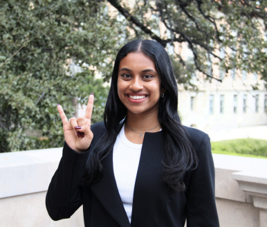

# Janavi Kolpekwar

## Bio

Janavi Kolpekwar is a Statistics & Data Sciences student at UT Austin with a passion for building at the intersection of AI, healthcare, and technology. She has worked on cancer diagnostics, developed software at Siemens EDA, and created EchoEase, an AI-driven tinnitus relief app. On campus, she helps lead Texas Guadaloop and Texas Enactus, and outside of work she enjoys tennis, music, and exploring new projects that blend creativity with tech.

## My Skills

- Data Science with R and Python
- Machine Learning & AI
- Web Development with RMarkdown and React
- Entrepreneurship & Business Strategy

## Education

B.S. in Statistics & Data Sciences | August 2022 - May 2026

**The University of Texas - Austin** | Austin, TX

## Experience

**R&D Software Engineering Intern** | Siemens | June 2025 - Present

**co-Head of Business** | Texas Guadaloop | April 2025 - Present

**AI/ML Research Analyst** | Navigo Health Systems | Sept 2024 - Present

**Undergraduate Student Researcher** | Oden Institute of CE (UT Austin) | Feb 2025 - Present

**Undergraduate Student Researcher** | Data,Discovery,Decision Lab (UT Austin) | Jan 2024 - July 2025

Last Build Time: 2025-08-31 14:58:27.138785